# Project 1_ Data101

```r
#Value vs Country
tapply(wo$Value,wo$Country,mean)
```

```
##               Afghanistan                   Albania                    Angola
##                 42.683333                  5.417778                 13.202222
##                   Armenia                Azerbaijan                Bangladesh
##                  9.553571                 32.666071                 14.719048
##                     Benin                   Bolivia              Burkina Faso
##                 13.845556                  7.707778                 20.393333
##                   Burundi                  Cambodia                  Cameroon
##                 27.692222                 19.460000                 22.748333
##                      Chad                  Colombia                   Comoros
##                 42.436667                  2.351111                 16.013889
##                     Congo Congo Democratic Republic             Cote d'Ivoire
##                 34.908333                 41.576111                 25.322222
##        Dominican Republic                     Egypt                   Eritrea
##                  1.585714                 21.679762                 46.186667
##                  Eswatini                  Ethiopia                     Gabon
##                 12.312222                 28.392222                 23.109444
##                    Gambia                     Ghana                 Guatemala
##                 26.373889                 12.137778                  4.197222
##                    Guinea                    Guyana                     Haiti
##                 40.256111                  8.945556                  6.399444
##                  Honduras                     India                 Indonesia
##                  5.776111                 23.210556                 13.020238
##                    Jordan                     Kenya           Kyrgyz Republic
##                 13.522963                 22.088889                 22.683951
##                   Lesotho                   Liberia                Madagascar
##                 18.512222                 18.919444                 16.122778
##                    Malawi                  Maldives                      Mali
##                  6.786111                 11.504167                 39.420000
##                   Moldova                   Morocco                Mozambique
##                 11.009259                 45.213333                  7.441111
##                   Myanmar                   Namibia                     Nepal
##                 23.656667                 13.601111                 12.700556
##                 Nicaragua                     Niger                   Nigeria
##                  6.618889                 29.211111                 18.623333
##                  Pakistan                      Peru               Philippines
##                 24.435119                  1.814444                  5.063333
##                    Rwanda     Sao Tome and Principe                   Senegal
##                 15.480556                 11.025862                 23.196667
##              Sierra Leone              South Africa                Tajikistan
##                 29.441111                  3.594828                 44.304444
##                  Tanzania               Timor-Leste                      Togo
##                 29.567778                 46.210000                 13.533333
##                    Turkey              Turkmenistan                    Uganda
##                  6.964103                 36.190000                 24.840556
##                   Ukraine                     Yemen                    Zambia
##                  3.692308                 27.621111                 24.361667
##                  Zimbabwe
##                 18.170556
```

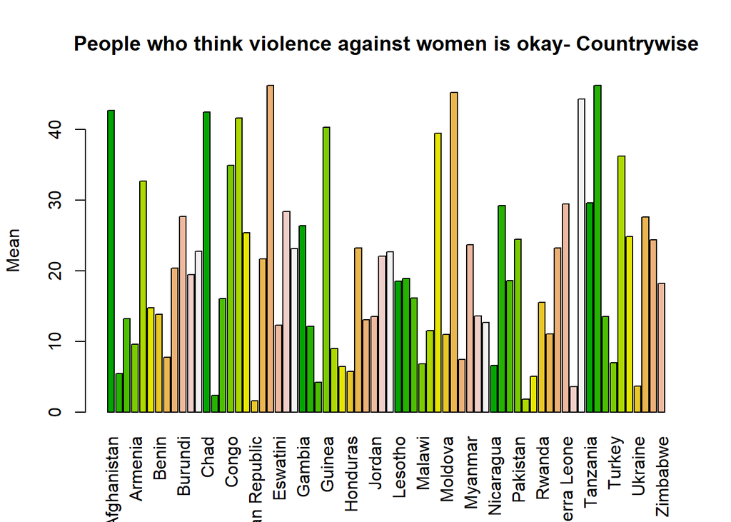

```r
barplot(tapply(wo$Value,wo$Country,mean),las=3,cex.names=1, col= terrain.colors(12), ylab= "Mean", main= "People who think violence against women is okay- Countrywise")
```

```r
#Value vs Gender
tapply(wo$Value,wo$Gender,mean)
```

```
##        F        M
## 22.93635 15.89720
```

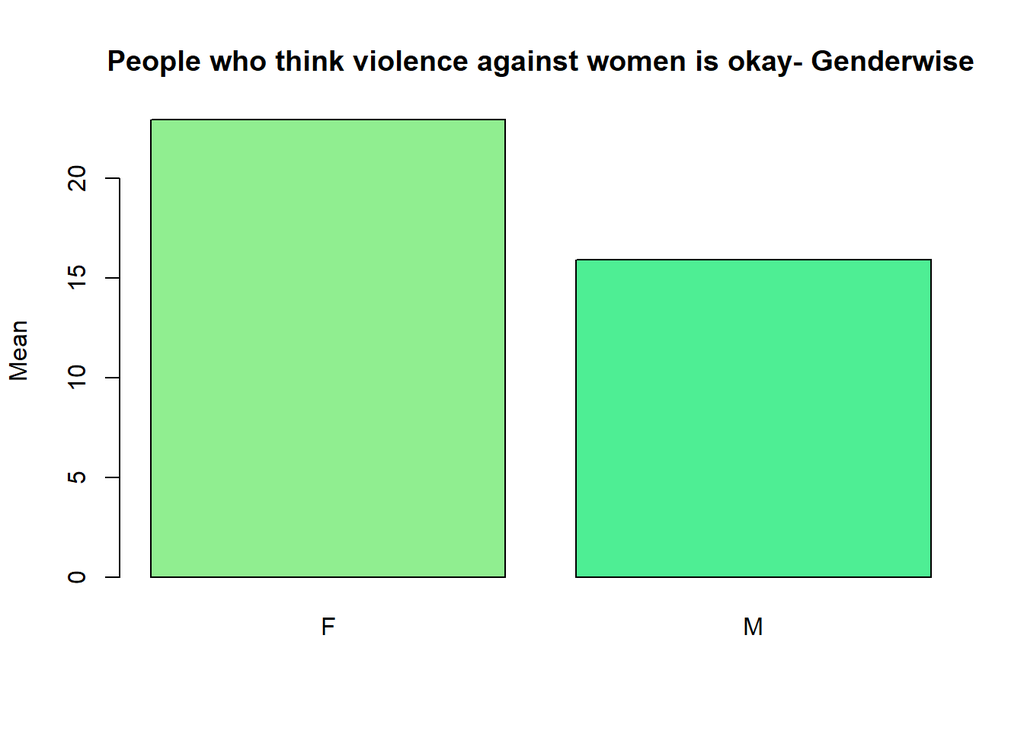

```r
barplot(tapply(wo$Value,wo$Gender,mean), col= c("palegreen2","seagreen2"), ylab= "Mean", main= "People who think violence against women is okay- Genderwise")
```

```r
#Value vs Demographic Questions
tapply(wo$Value,wo$Demographics.Question,mean)
```

```
##            Age      Education     Employment Marital status      Residence
##       20.04138       18.47760       21.16938       19.87843       19.59492
```

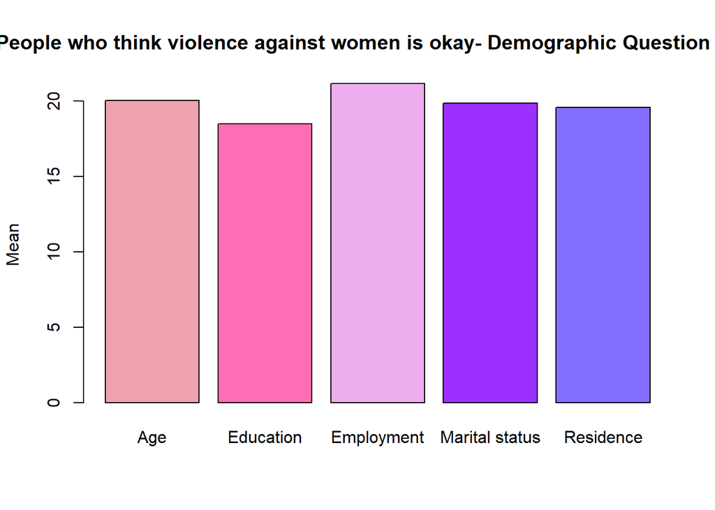

```r
barplot(tapply(wo$Value,wo$Demographics.Question,mean), col= c("lightpink2","hotpink1","plum2","purple1","slateblue1"), ylab= "Mean", main= "People who think violence against women is okay- Demographic Question wise")
```

```r
#Value vs Demographic Response
##Age
tapply(wo[wo$Demographics.Question=='Age',]$Value,wo[wo$Demographics.Question=='Age',]$Demographics.Response,mean)
```

```
##    15-24    25-34    35-49
## 21.08417 19.70356 19.33641
```

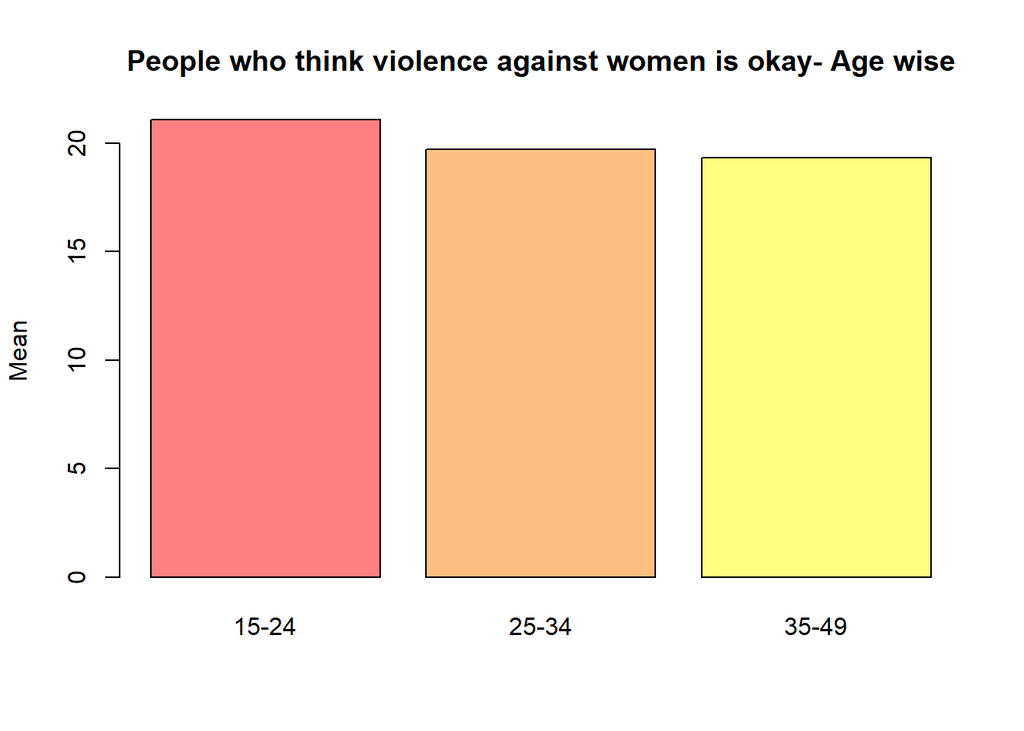

```r
barplot(tapply(wo[wo$Demographics.Question=='Age',]$Value,wo[wo$Demographics.Question=='Age',]$Demographics.Response,mean), col = hsv(seq(0,1 - 1/12,length.out = 12), 0.5 , 1), ylab= "Mean", main= "People who think violence against women is okay- Age wise")
```

```r
##Marital Status
tapply(wo[wo$Demographics.Question=='Marital status',]$Value,wo[wo$Demographics.Question=='Marital status',]$Demographics.Response,mean)
```

```
##   Married or living together                Never married
##                     20.18100                     18.70436
## Widowed, divorced, separated
##                     20.68351
```

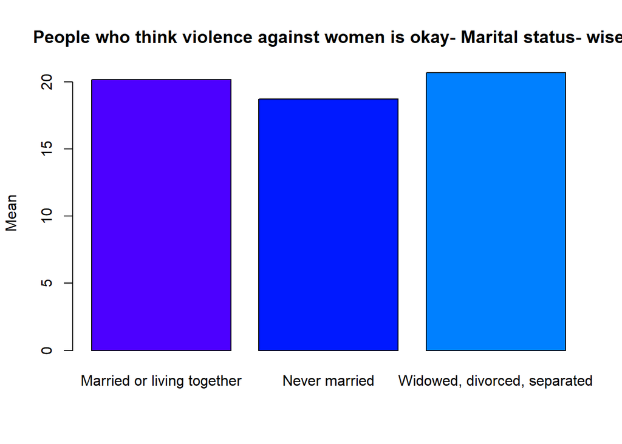

```r
barplot(tapply(wo[wo$Demographics.Question=='Marital status',]$Value,wo[wo$Demographics.Question=='Marital status',]$Demographics.Response,mean), col= topo.colors(12),ylab= "Mean", main= "People who think violence against women is okay- Marital status- wise")
```

```r
##Education
tapply(wo[wo$Demographics.Question=='Education',]$Value,wo[wo$Demographics.Question=='Education',]$Demographics.Response,mean)
```

```
##       Higher No education      Primary    Secondary
##      8.89867     25.40312     22.81909     17.37889
```

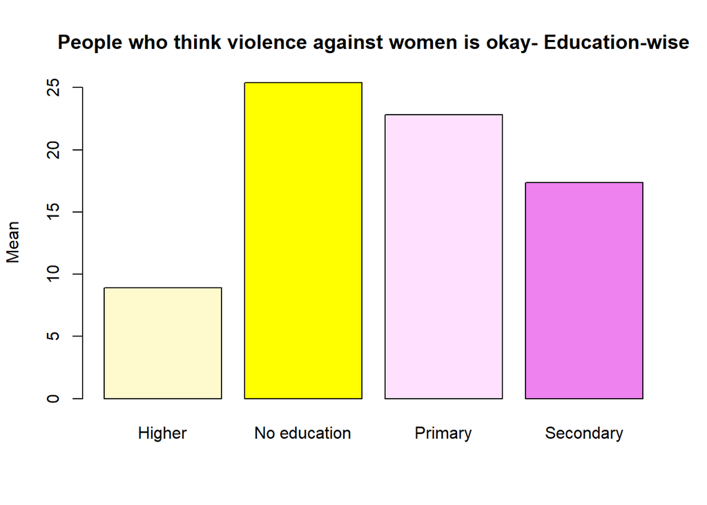

```r
barplot(tapply(wo[wo$Demographics.Question=='Education',]$Value,wo[wo$Demographics.Question=='Education',]$Demographics.Response,mean), col= c("lemonchiffon","yellow1","thistle1","violet","slateblue2","lightpink"),ylab= "Mean", main= "People who think violence against women is okay- Education-wise")
```

```r
##Employment
tapply(wo[wo$Demographics.Question=='Employment',]$Value,wo[wo$Demographics.Question=='Employment',]$Demographics.Response,mean)
```

```
## Employed for cash Employed for kind        Unemployed
##          19.55380          24.44554          19.53971
```

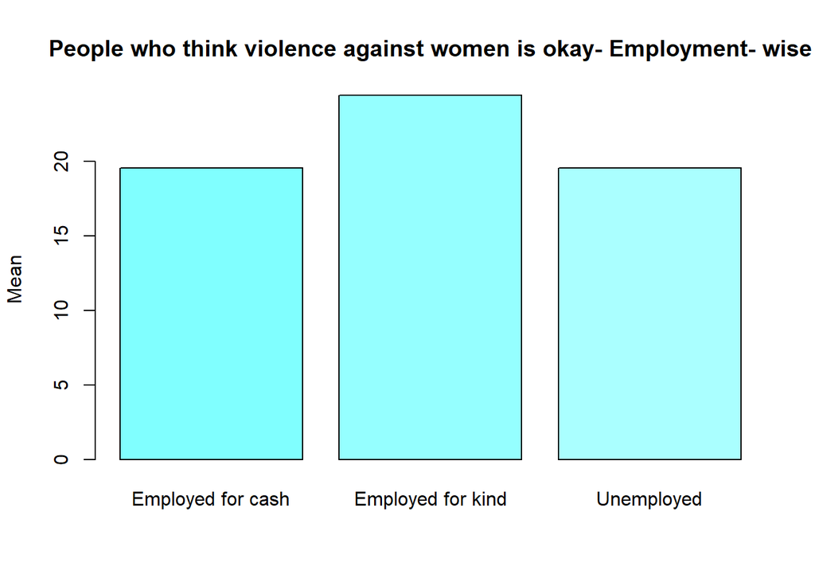

```r
barplot(tapply(wo[wo$Demographics.Question=='Employment',]$Value,wo[wo$Demographics.Question=='Employment',]$Demographics.Response,mean), col= cm.colors(12),ylab= "Mean", main= "People who think violence against women is okay- Employment- wise")
```

```r
##Residence
tapply(wo[wo$Demographics.Question=='Residence',]$Value,wo[wo$Demographics.Question=='Residence',]$Demographics.Response,mean)
```

```
##    Rural    Urban
## 23.29406 15.89578
```

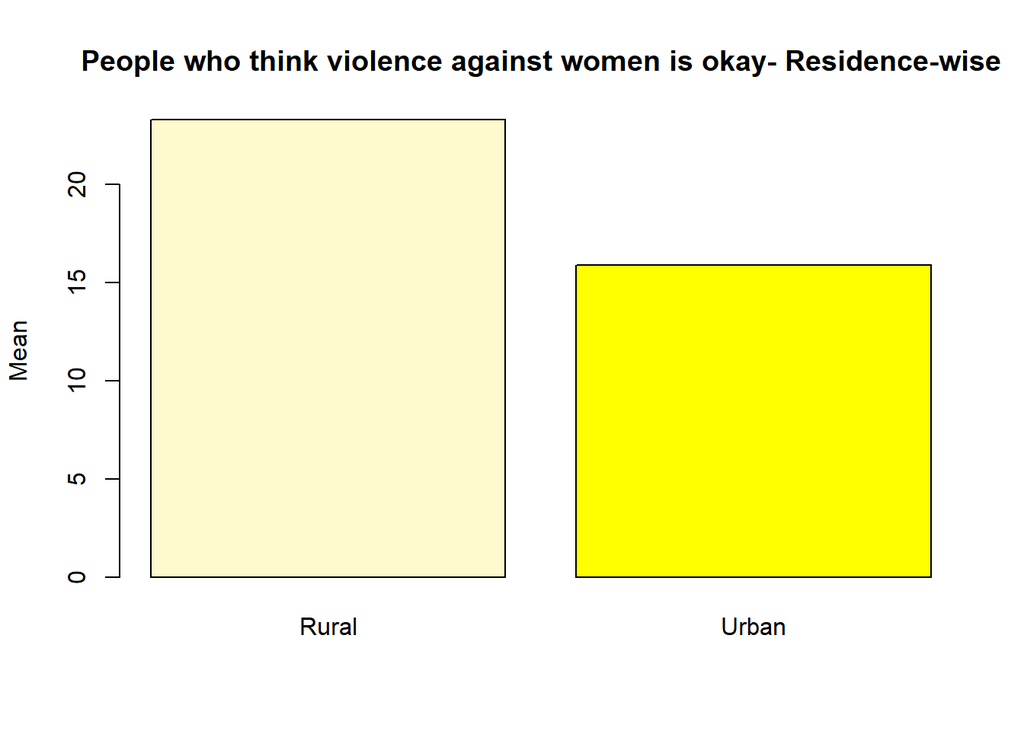

```r
barplot(tapply(wo[wo$Demographics.Question=='Residence',]$Value,wo[wo$Demographics.Question=='Residence',]$Demographics.Response,mean), col= c("lemonchiffon","yellow1","thistle1","violet","slateblue2","lightpink"),ylab= "Mean", main= "People who think violence against women is okay- Residence-wise")
```

## More Plots

Women got beaten for at least one or more specific reason

```r
unique(wo$Question)
```

```
## [1] "Burning food"              ">=1 reason"
## [3] "Arguing"                   "Going out without telling"
## [5] "Neglecting children"       "Refusing to have sex"
```

```r
tapply(wo$Value,wo$Question,mean)
```

```
##                >=1 reason                   Arguing              Burning food
##                 33.217152                 18.983652                  9.203445
## Going out without telling       Neglecting children      Refusing to have sex
##                 20.046321                 23.461249                 13.209613
```

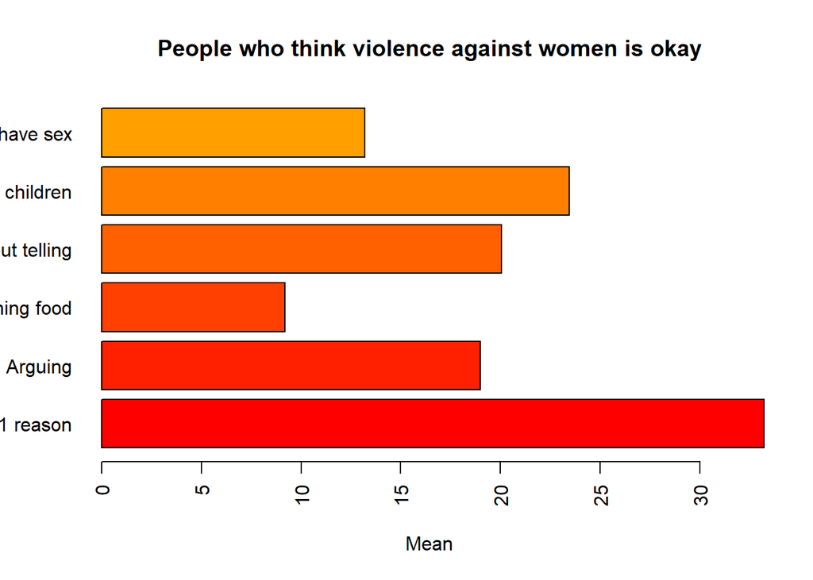

```r
woquestion <- tapply(wo$Value,wo$Question,mean)
barplot(tapply(wo$Value,wo$Question,mean),las=2, cex.names=1, col = heat.colors(12), horiz = TRUE,xlab= "Mean", main= "People who think violence against women is okay")
```

##Is there any correlation between demographics and the reason women get beaten? *Age-wise*

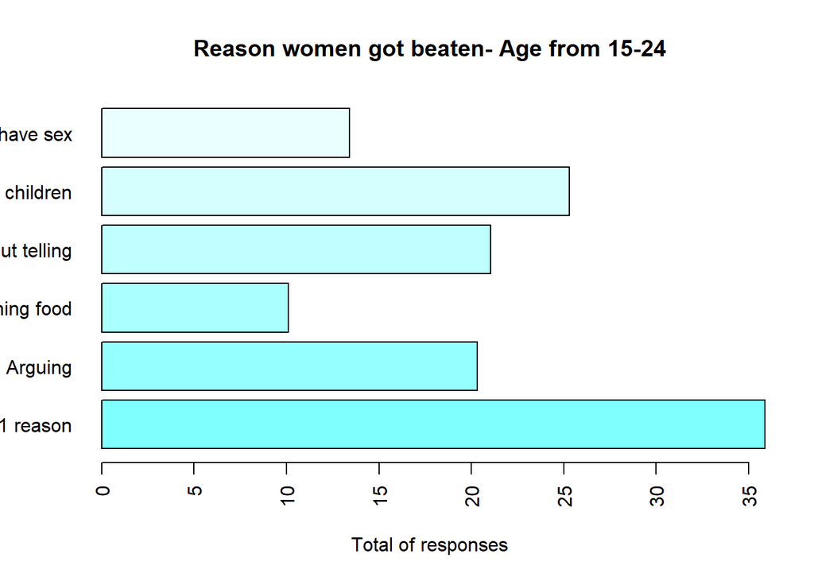

```r
wo1 <- tapply(wo[wo$Demographics.Question=='Age'& wo$Demographics.Response =='15-24',]$Value,wo[wo$Demographics.Question=='Age'& wo$Demographics.Response =='15-24',]$Question,mean)
barplot(wo1,horiz= TRUE, col = cm.colors(12),las=2, cex.names=1, xlab = "Total of responses", main = "Reason women got beaten- Age from 15-24")
```

[figure not shown]

```r
wo2 <- tapply(wo[wo$Demographics.Question=='Age'& wo$Demographics.Response =='25-34',]$Value,wo[wo$Demographics.Question=='Age'& wo$Demographics.Response =='25-34',]$Question,mean)
barplot(wo1,horiz= TRUE, col = terrain.colors(12),las=2, cex.names=1, xlab = "Total of responses", main = "Reason women got beaten- Age from 25-34")
```

[figure not shown]

```r
wo3 <- tapply(wo[wo$Demographics.Question=='Age'& wo$Demographics.Response =='35-49',]$Value,wo[wo$Demographics.Question=='Age'& wo$Demographics.Response =='35-49',]$Question,mean)
barplot(wo1,horiz= TRUE, col = hsv(seq(0,1 - 1/12,length.out = 12)), 1 , 1,las=2, cex.names=1, xlab = "Total of responses", main = "Reason women got beaten- Age from 35-49")
```

*Education-wise*

[figure not shown]

```r
wo11 <- tapply(wo[wo$Demographics.Question=='Education'& wo$Demographics.Response =='No education',]$Value,wo[wo$Demographics.Question=='Education'& wo$Demographics.Response =='No education',]$Question,mean)
barplot(wo1,horiz= TRUE, col = cm.colors(12),las=2, cex.names=1, xlab = "Total of responses", main = "Reason women got beaten- Uneducated")
```

[figure not shown]

```r
wo22 <- tapply(wo[wo$Demographics.Question=='Education'& wo$Demographics.Response =='Primary',]$Value,wo[wo$Demographics.Question=='Education'& wo$Demographics.Response =='Primary',]$Question,mean)
barplot(wo1,horiz= TRUE, col = terrain.colors(12),las=2, cex.names=1, xlab = "Total of responses", main = "Reason women got beaten- Primary school level")
```

[figure not shown]

```r
wo33 <- tapply(wo[wo$Demographics.Question=='Education'& wo$Demographics.Response =='Secondary',]$Value,wo[wo$Demographics.Question=='Education'& wo$Demographics.Response =='Secondary',]$Question,mean)
barplot(wo1,horiz= TRUE, col = hsv(seq(0,1 - 1/12,length.out = 12)), 1 , 1,las=2, cex.names=1, xlab = "Total of responses", main = "Reason women got beaten- Secondary school level")
```

[figure not shown]

```r
wo44 <- tapply(wo[wo$Demographics.Question=='Education'& wo$Demographics.Response =='Higher',]$Value,wo[wo$Demographics.Question=='Education'& wo$Demographics.Response =='Higher',]$Question,mean)
barplot(wo1,horiz= TRUE, col = hsv(seq(0,1 - 1/12,length.out = 12)), 1 , 1,las=2, cex.names=1, xlab = "Total of responses", main = "Reason women got beaten- Higher school level")
```

**Employment-wise**

[figure not shown]

```r
wo111 <- tapply(wo[wo$Demographics.Question=='Employment'& wo$Demographics.Response =='Employed for kind',]$Value,wo[wo$Demographics.Question=='Employment'& wo$Demographics.Response =='Employed for kind',]$Question,mean)
barplot(wo1,horiz= TRUE, col = cm.colors(12),las=2, cex.names=1, xlab = "Total of responses", main = "Reason women got beaten- Employed for kind")
```

[figure not shown]

```r
wo222 <- tapply(wo[wo$Demographics.Question=='Employment'& wo$Demographics.Response =='Employed for cash',]$Value,wo[wo$Demographics.Question=='Employment'& wo$Demographics.Response =='Employed for cash',]$Question,mean)
barplot(wo1,horiz= TRUE, col = terrain.colors(12),las=2, cex.names=1, xlab = "Total of responses", main = "Reason women got beaten- Employed for cash")
```

[figure not shown]

```r
wo33 <- tapply(wo[wo$Demographics.Question=='Employment'& wo$Demographics.Response =='Unemployed',]$Value,wo[wo$Demographics.Question=='Employment'& wo$Demographics.Response =='Unemployed',]$Question,mean)
barplot(wo1,horiz= TRUE, col = hsv(seq(0,1 - 1/12,length.out = 12)), 1 , 1,las=2, cex.names=1, xlab = "Total of responses", main = "Reason women got beaten- Unemployed")
```

**Testing hypotheses**

Ho: women who are uneducated think it is okay when “A husband is justified in hitting or beating his wife if she argues with him” have the same average mean value as men who are uneducated. Ha1: women who are uneducated think it is okay when “A husband is justified in hitting or beating his wife if she argues with him” have the higher average mean value as men who are uneducated.

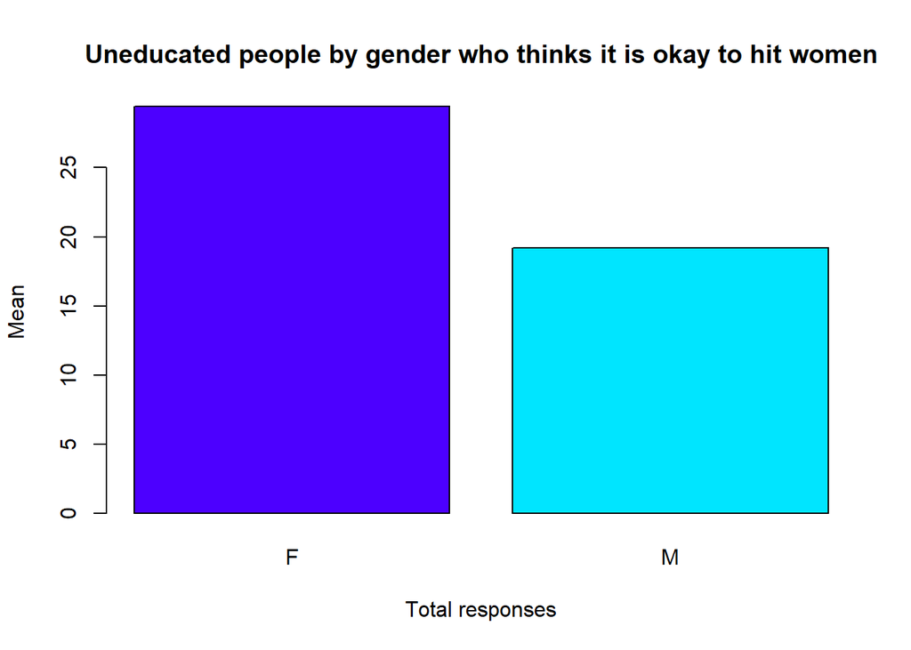

```r
barplot(tapply(wo[wo$Question== 'Arguing'& wo$Demographics.Response== 'No education',]$Value,wo[wo$Question== 'Arguing'& wo$Demographics.Response== 'No education',]$Gender,mean), col= topo.colors(2),xlab= "Total responses", ylab= "Mean",main="Uneducated people by gender who thinks it is okay to hit women")
```

```r
women1 <- subset(wo[wo$Question== 'Arguing'& wo$Demographics.Response== 'No education',],select = c(3,8))
mean(women1[women1$Gender== 'F',]$Value)
```

```
## [1] 29.43594
```

```r
mean(women1[women1$Gender== 'M',]$Value)
```

```
## [1] 19.20588
```